# Relative healthcare use (Albuminuria with eGFR >60)

**Inpatient days**

Inpatient days (overall)

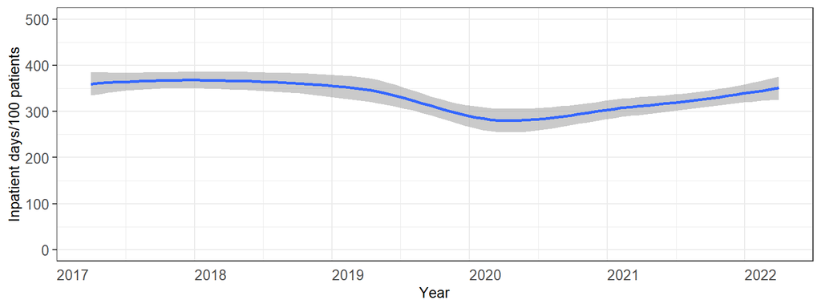

Inpatient days by ethnicity

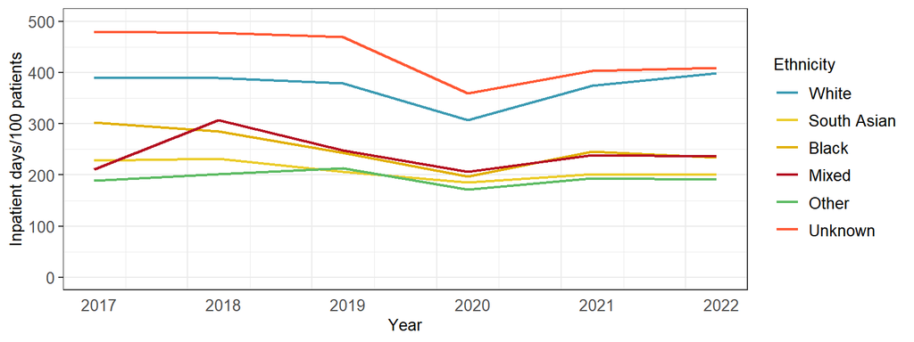

Inpatient days by IMD

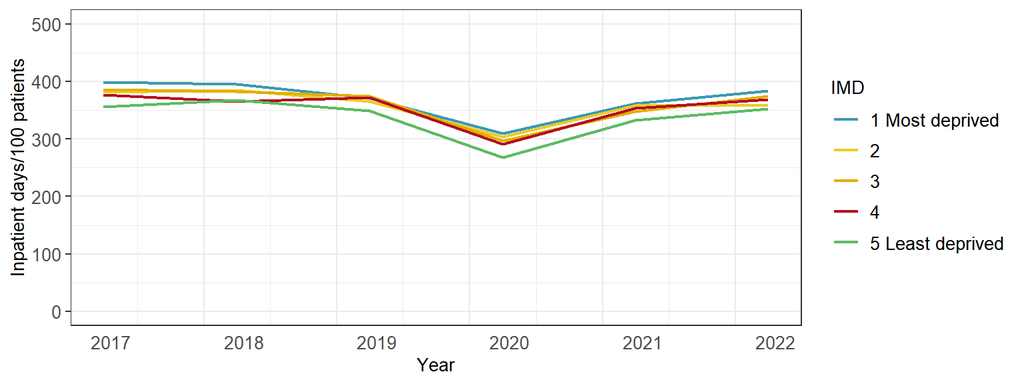

Inpatient days by region

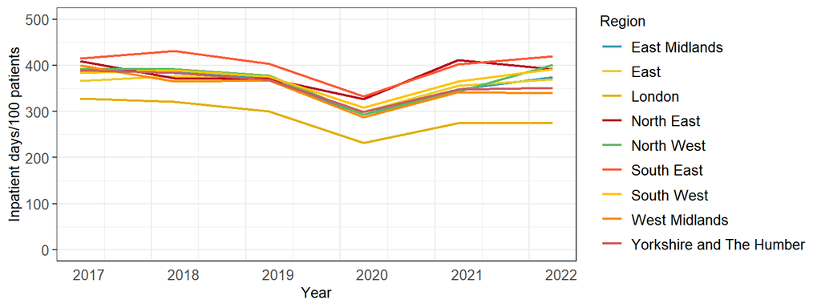

Inpatient days by rural/urban

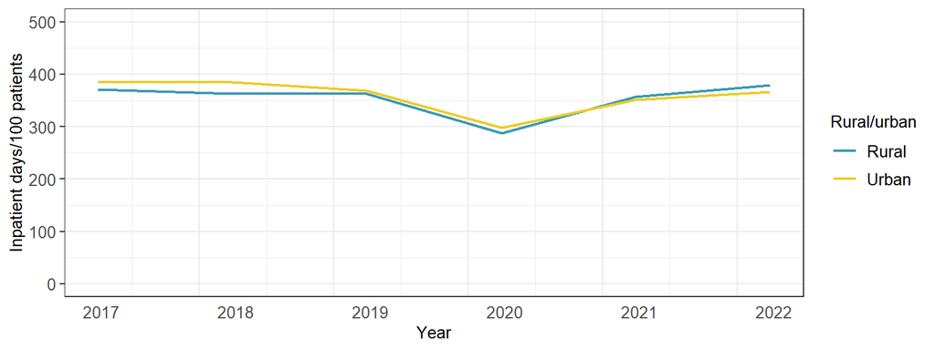

**ICU days**

ICU days (overall)

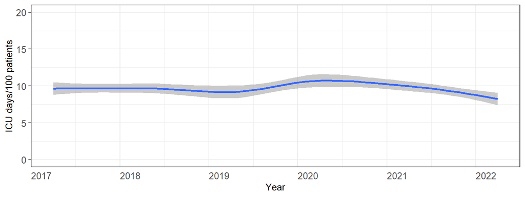

ICU days by ethnicity

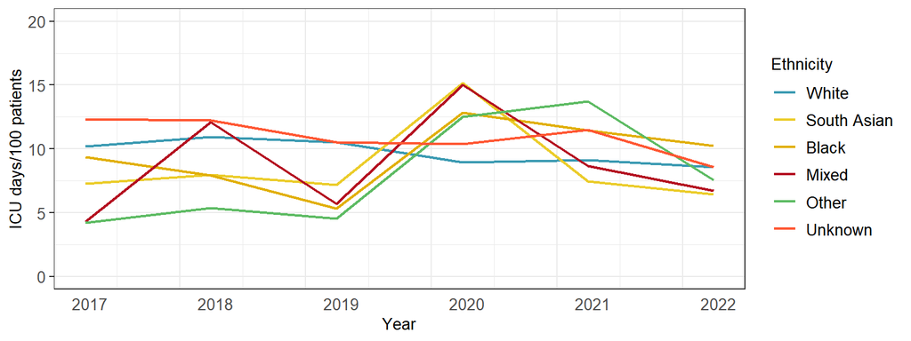

ICU days by IMD

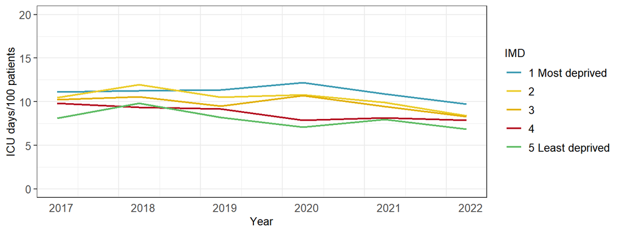

ICU days by region

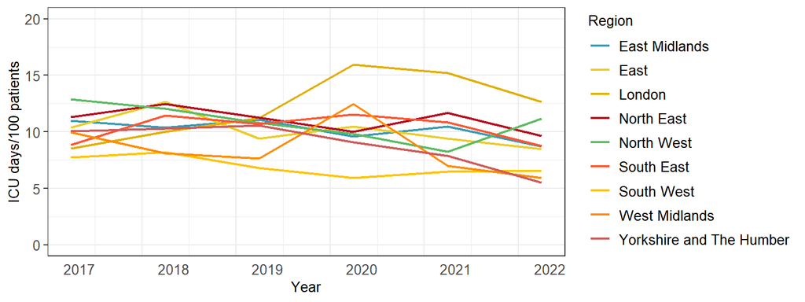

ICU days by rural/urban

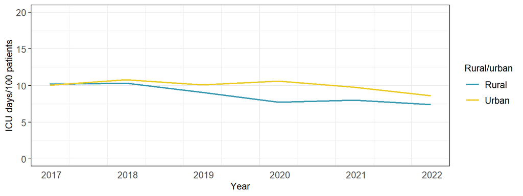

**ED presentations**

ED presentations (overall)

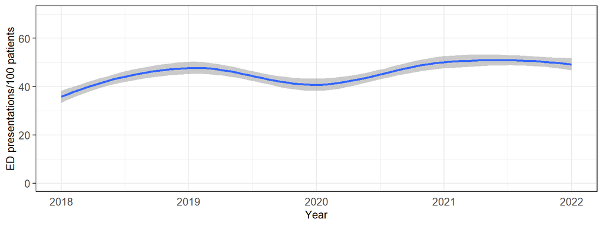

ED presentations by ethnicity

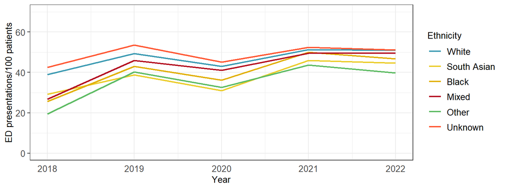

ED presentations by IMD

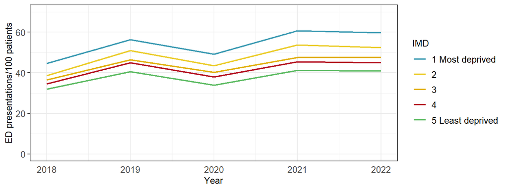

ED presentations by region

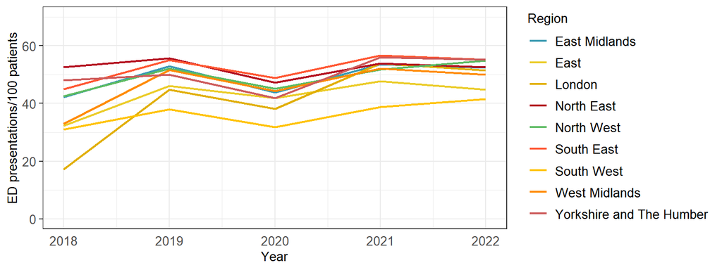

ED presentations by rural/urban

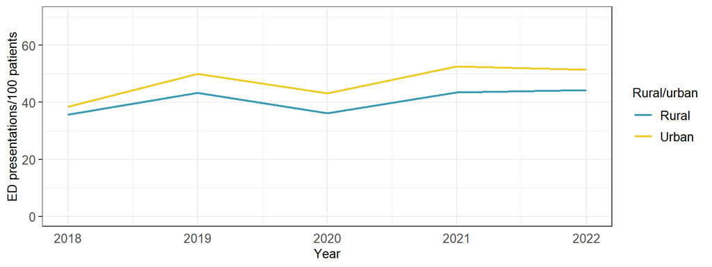

**Outpatient appointments**

Outpatient appointments (overall)

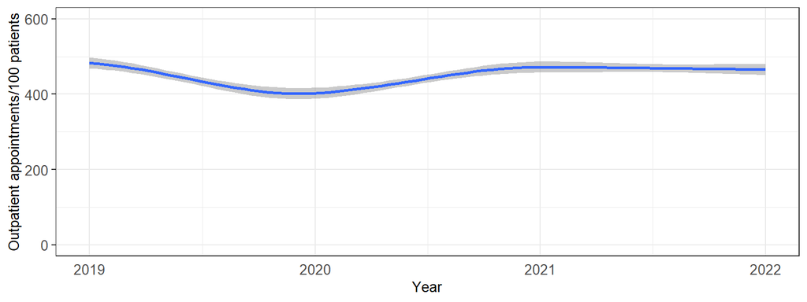

Outpatient appointments by ethnicity

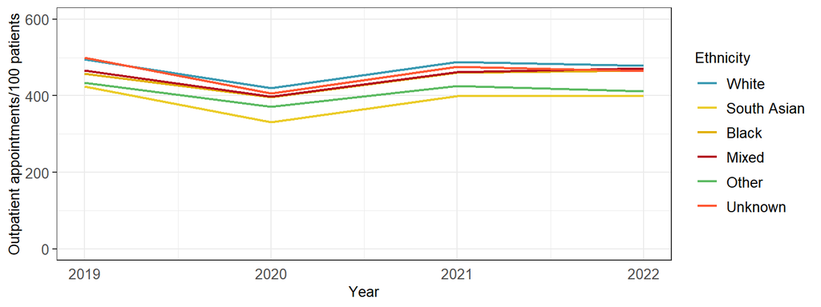

Outpatient appointments by IMD

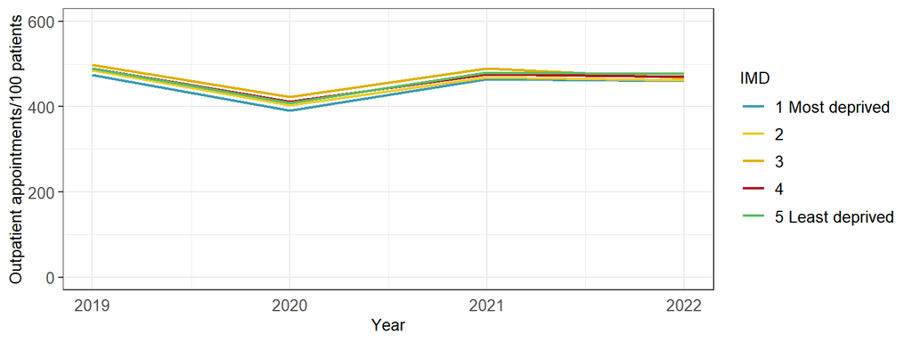

Outpatient appointments by region

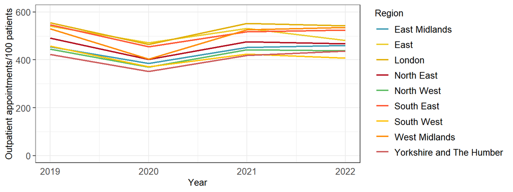

Outpatient appointments by rural/urban

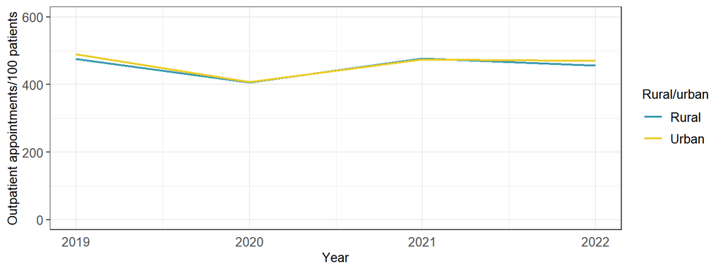

**Nephrology appointments**

Nephrology appointments (overall)

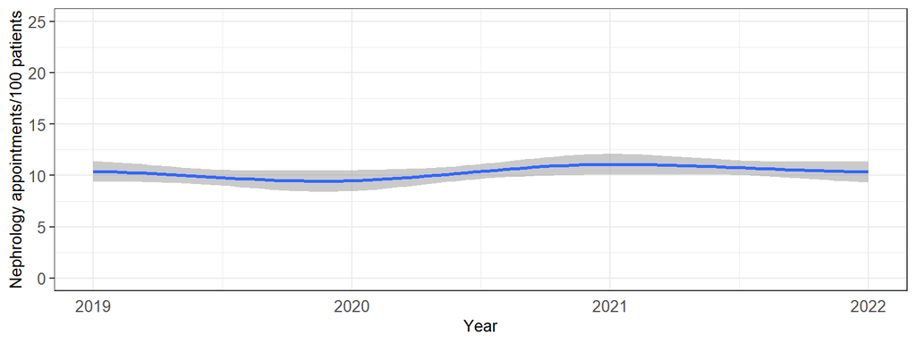

Nephrology appointments by ethnicity

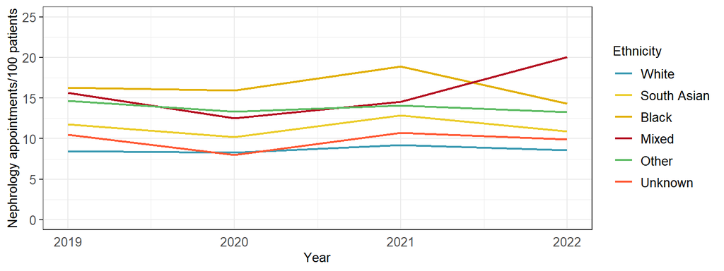

Nephrology appointments by IMD

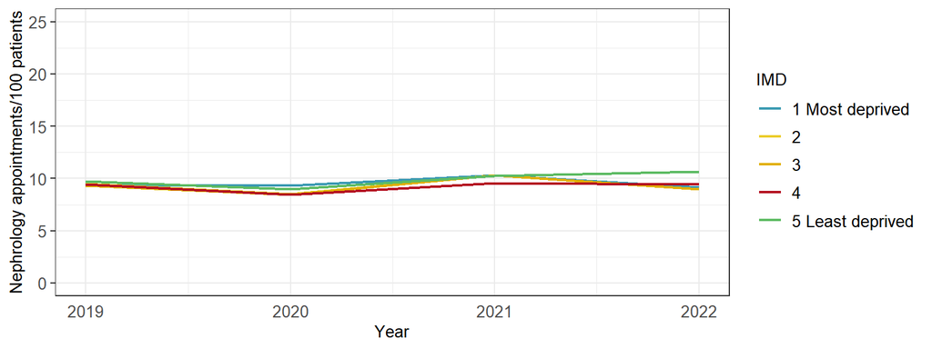

Nephrology appointments by region

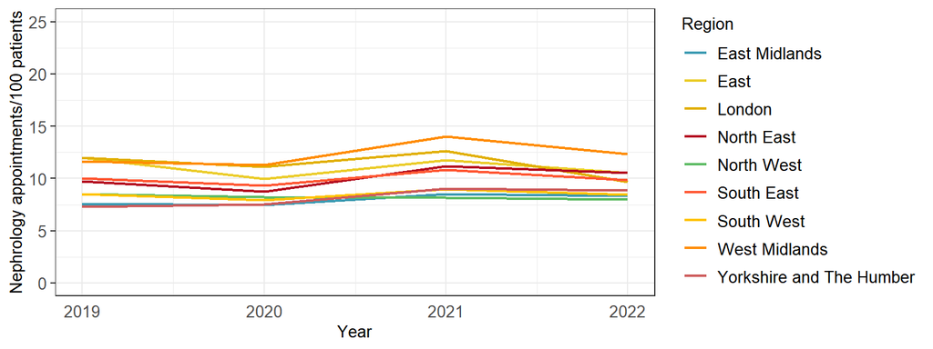

Nephrology appointments by rural/urban

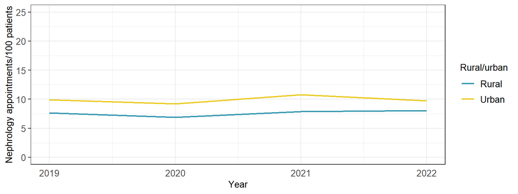

**GP interactions**

GP interactions (overall)

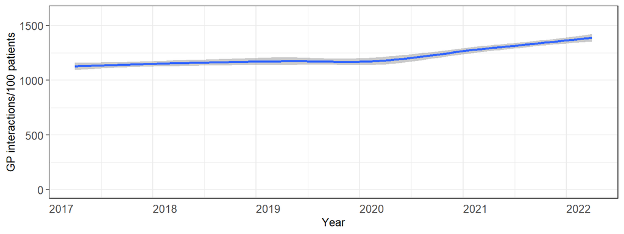

GP interactions by ethnicity

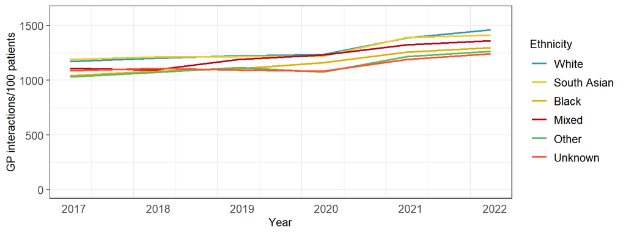

GP interactions by IMD

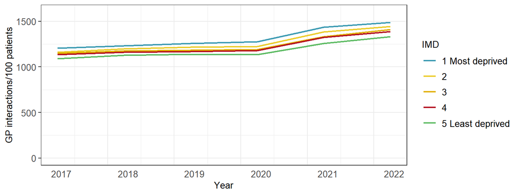

GP interactions by region

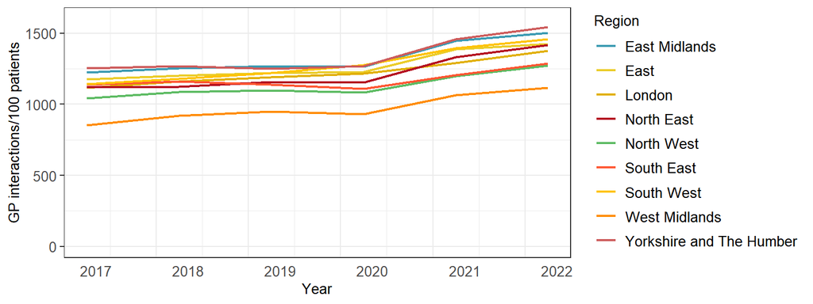

GP interactions by rural/urban

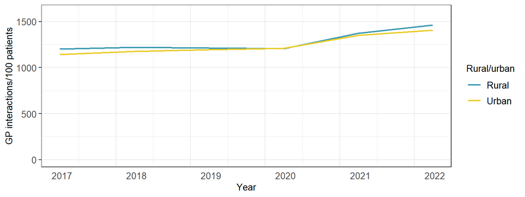

**Blood pressure measurements**